# Data Analysis

Daniel Pedrini

2023-04-13

### Instanciando as bibliotecas

# Início da Análise dos dados

## Veificar o percentual de Usuários Casuais e Usuários Membros

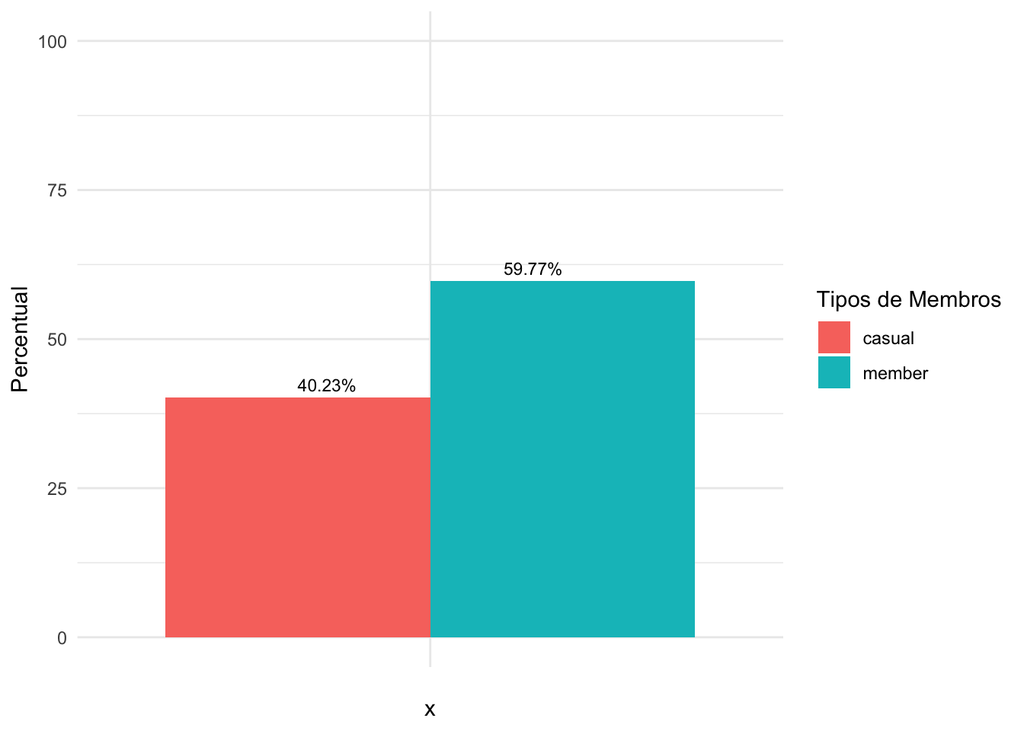

## Verificar o percentual do uso de cada tipo de bicicleta

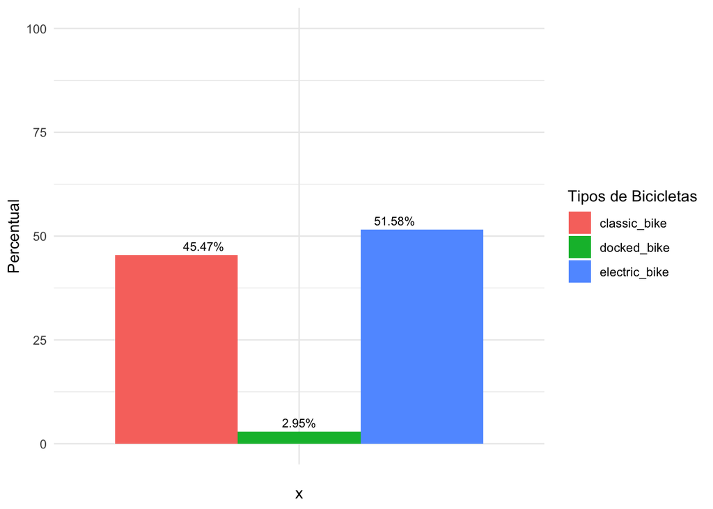

## Vamos verificar a distribuição da distância percorrida pelos ciclistas

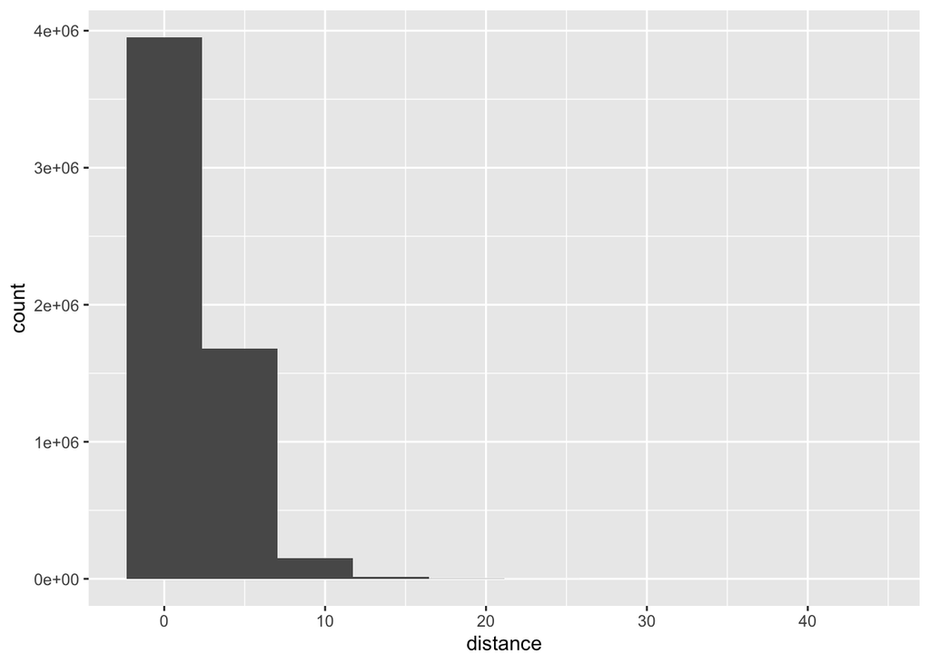

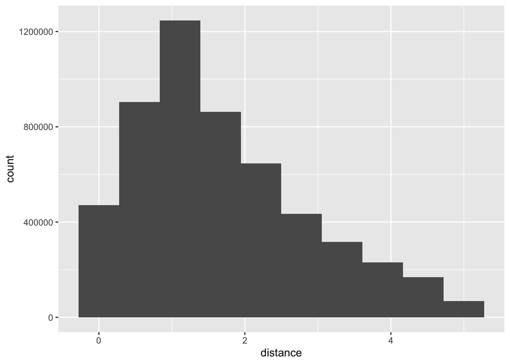

### OBS: Mesmo com esses outliers, não serão realizadas nenhuma alteração nos dados. Vamos trabalhar com as informações que temos. Todos os dados existentes são reais e já estão tratados.

## Calcular as distâncias máximas, médias e mínimas percorridas

Nota: estamos eliminando aqui os outliers. Distancias acima de 5km

```
##   max(distance) min(distance) mean(distance)
## 1      4.999991             0       1.691842
```

## Calcular o percentual de usuários por dia da semana

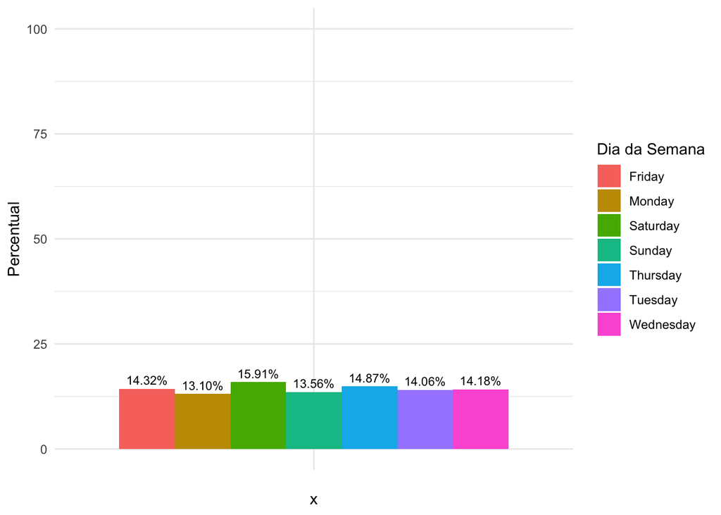

## Calcular o percentual de utilização por mês

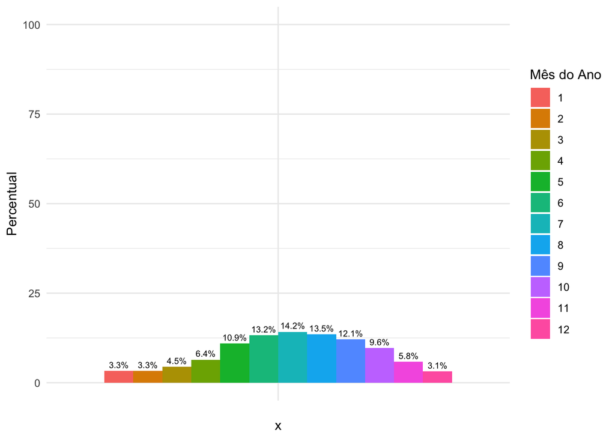

## Calcular percentual de ciclista que pegam bicicleta no horário de trabalho

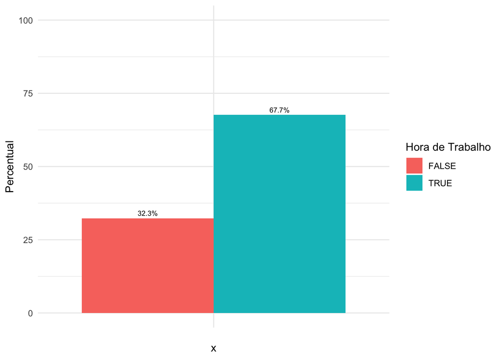

```r
percentage_working_time <- prop.table(table(df$working_hour, useNA = "no")) *100
df_working_time <- as.data.frame(percentage_working_time)
colnames(df_working_time)  <- c("Valor", "Percentual")


ggplot(df_working_time, aes(x="", y= Percentual, fill = Valor))+
  geom_bar(stat="identity", position = "dodge") +
  geom_text(aes(label = sprintf("%.1f%%", Percentual)), vjust = -0.5, color = "black", size = 2.5, position = position_dodge(width = 0.9))+
  scale_fill_discrete(name="Hora de Trabalho")+
  ylab("Percentual")+
  ylim(0,100)+
  theme_minimal()
```

# Agora vamos para análise comparativa entre os usuários membros e os usuários casuais

## Verificar o percentual do uso de cada tipo de bicicleta por tipo de usuário

Nota: Algumas observações comparativas: - 7% dos usuários Casuais utilizam as bicicletas para passeios com seus filhos(as), que são as docked_bikes. O mesmo comportamento não aparece nos usuários membros. - 5% a mais dos usuários casuais optam por bicicletas elétricas.

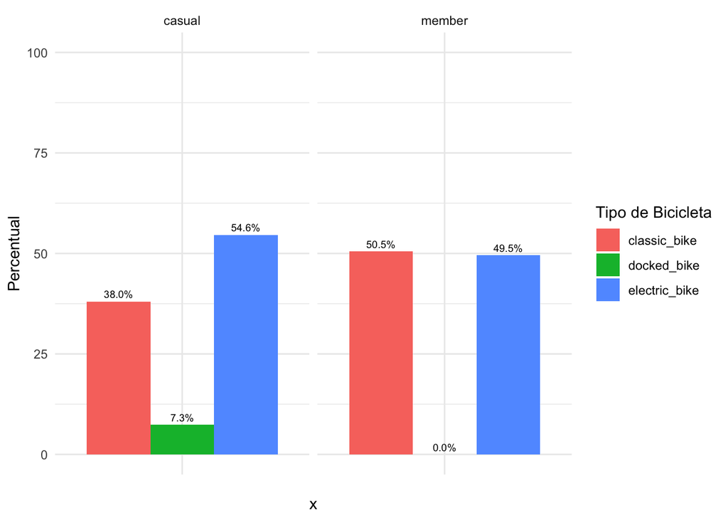

## Verificar o percetual de uso por dia de semana de forma comparativa entre casuais e membros

Nota: Algumas observações comparativas: - Os usuários casuáis utilizam mais as bicicletas durante os finais de semanas (sábado e domingo) e os membros durante a semana, não usando muito durante o fim de semana

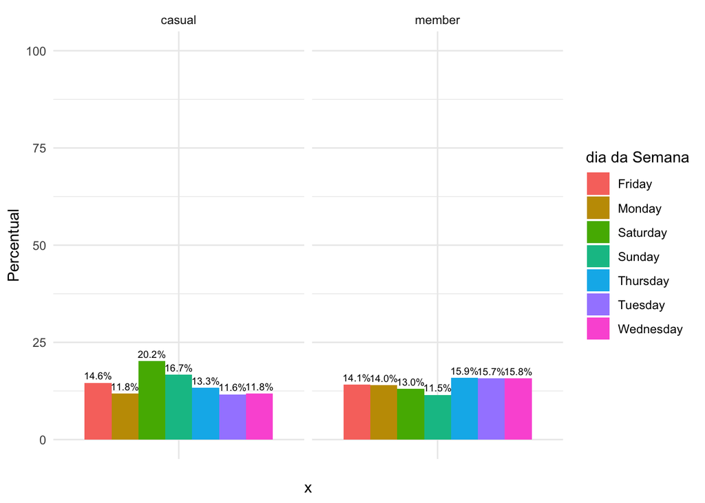

## Verificar o percentual de utilização por mês comparativamente Nota: Algumas observações comparativas: - Aqui vemos uma curva muito mais acentuada dos usuários casuais utilizando as bicicletas nos meses mais quentes, e períodos de férias, e os usuários membros utilizando as bicicletas de forma mais distribuídas.

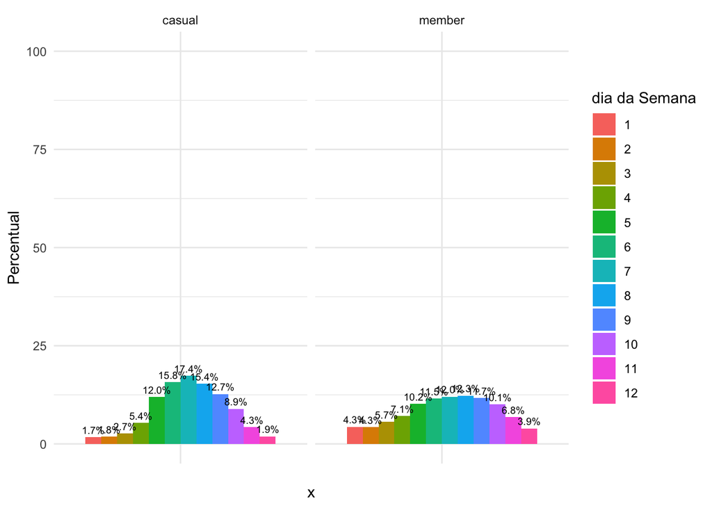

## Veificar percentual de uso no horário de trabalho por tipo de membro Nota: Algumas observações comparativas: - há uma diferença, mas não tão significativa. Os usuários casuais usam mais as bicicletas fora do horário comercial, 6% a mais, que os usuários membros

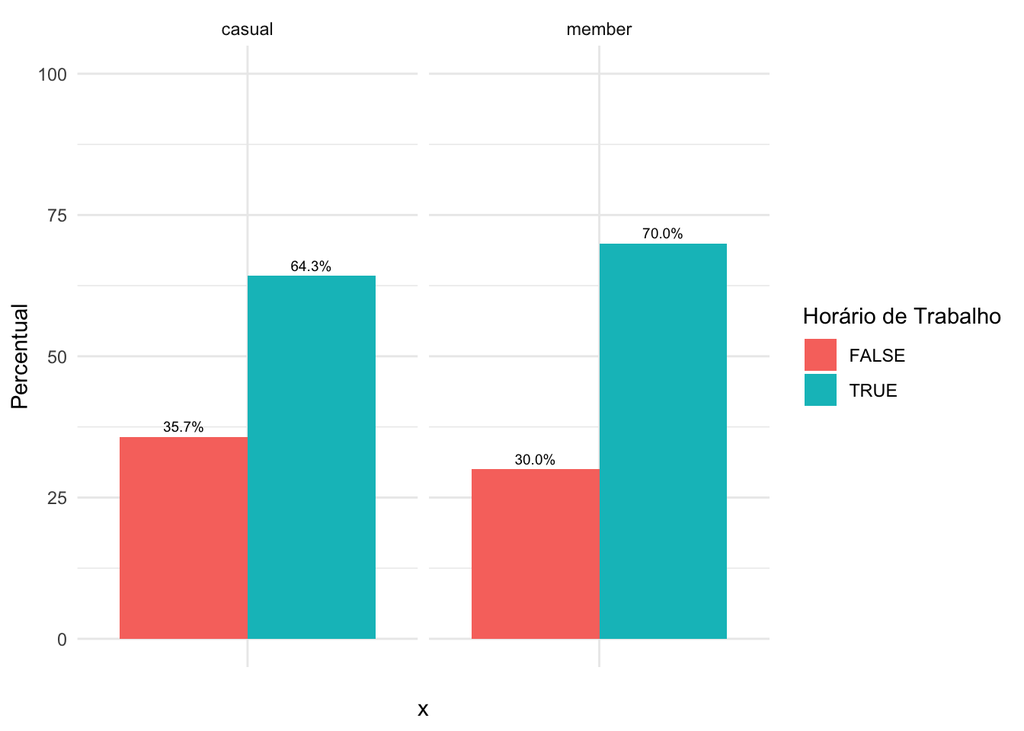

## Verificar a distancia maxima, minima e media por tipo de membro Nota: Algumas observações comparativas: - Em termos de distância, não há discrepância entre os usuários casuais e os usuários membros relevantes.

```r
summarise_distance_member <- df %>% filter(distance < 5 & member_casual == "member") %>% summarise(max_distance = max(distance), min_distance = min(distance), mean_distance = mean(distance))
summarise_distance_casual <- df %>% filter(distance < 5 & member_casual == "casual") %>% summarise(max_distance = max(distance), min_distance = min(distance), mean_distance = mean(distance))
print(summarise_distance_member)
```

```
##   max_distance min_distance mean_distance
## 1     4.999991            0      1.669354
```

```r
print(summarise_distance_casual)
```

```
##   max_distance min_distance mean_distance
## 1     4.999989            0        1.7253
```